# Machine Learning for Investing and Trading

## Background

Investment banks, hedge funds - even individual investors - develop financial models to predict price movements in publicly-traded securities. Successfully anticipating these movements can prove highly profitable for the investor; at the same time, a misstep could spell financial ruin. Historical stock prices provide a treasure trove of data, which may be suitable for machine learning algorithms to predict future stock price movements and - ultimately - drive more well-informed investment decisions. In this work, we build a stock price predictor that predicts stock price movements - specifically whether a price will rise or fall - based on historical performance.

We'll look at a few of the most valuable companies in the world, as measured by total market capitalization (market cap), spanning several industries:

- Tesla (**TSLA**, automotive)
- Johnson & Johnson (**JNJ**, pharmaceutical)
- The Coca-Cola Company (**KO**, beverage)
- Apple (**AAPL**, electronics)
- ExxonMobile (**XOM**, energy / oil & gas)
- JPMorgan Chase (**JPM**, financial services)

For comparative metrics (*e.g.*, price movements relative to the overall market, which is captured in a parameter referred to as **beta**), we'll use an extremely popular index fund, the SPDR S&P 500 ETF (**SPY**, or "Spyder"), which invests in the entire S&P 500 index.

## Exploration

To start, we'll look at a single stock—Tesla—along with the SPY index fund to get a feel for financial data and build intuition for what inputs may be useful in building out a predictive machine learning model.

```python
import numpy as np
import pandas as pd
import matplotlib.pyplot as plt
import seaborn as sns
import time
from datetime import datetime, timedelta
from sklearn.ensemble import RandomForestClassifier
from sklearn.model_selection import TimeSeriesSplit, GridSearchCV, train_test_split
from sklearn.metrics import accuracy_score
```

```python
# Import data
SPY = pd.read_csv('SPY.csv')   # SPDR S&P 500 ETF S&P 500 index
TSLA = pd.read_csv('TSLA.csv') # Tesla
JPM  = pd.read_csv('JPM.csv')  # JPMorgan Chase
AAPL = pd.read_csv('AAPL.csv') # Apple
XOM  = pd.read_csv('XOM.csv')  # ExxonMobile
KO   = pd.read_csv('KO.csv')   # Coca-Cola Company
JNJ  = pd.read_csv('JNJ.csv')  # Johnson & Johnson

# Assign names to dataframes
SPY.name  = 'SPDR S&P 500 ETF'
TSLA.name = 'Tesla'
JPM.name  = 'JPMorgan Chase'
AAPL.name = 'Apple'
XOM.name  = 'ExxonMobil'
KO.name   = 'Coke'
JNJ.name  = 'Johnson & Johnson'
```

```python
SPY.head()
```

|  | Date | Open | High | Low | Close | Adj Close | Volume |
| --- | --- | --- | --- | --- | --- | --- | --- |
| 0 | 2015-01-02 | 206.380005 | 206.880005 | 204.179993 | 205.429993 | 187.074585 | 121465900 |
| 1 | 2015-01-05 | 204.169998 | 204.369995 | 201.350006 | 201.720001 | 183.696091 | 169632600 |
| 2 | 2015-01-06 | 202.089996 | 202.720001 | 198.860001 | 199.820007 | 181.965881 | 209151400 |
| 3 | 2015-01-07 | 201.419998 | 202.720001 | 200.880005 | 202.309998 | 184.233383 | 125346700 |
| 4 | 2015-01-08 | 204.009995 | 206.160004 | 203.990005 | 205.899994 | 187.502594 | 147217800 |

```python
SPY.info()
```

```
<class 'pandas.core.frame.DataFrame'>
RangeIndex: 1223 entries, 0 to 1222
Data columns (total 7 columns):
Date         1223 non-null object
Open         1223 non-null float64
High         1223 non-null float64
Low          1223 non-null float64
Close        1223 non-null float64
Adj Close    1223 non-null float64
Volume       1223 non-null int64
dtypes: float64(5), int64(1), object(1)
memory usage: 67.0+ KB
```

```python
type(SPY.Date[0])
```

```
str
```

Data types look right for Open, High, Low, Close, Adj Close, and Volume. We'll want to change the datatype for Date from string to datetime.

Process the data with some common financial analysis metrics to generate a new dataframe, which will be used in the machine learning model. The following features will be used (additional examples are mentioned [here](http://ahmedas91.github.io/blog/2016/07/01/predicting-us-equities-trends-using-random-forests/), and elaborated further in its own references):

$$K = \frac{(C - L_{14})}{(H_{14} - L_{14})}*100$$

- **Fast Stochastic Indicator:** Simple 3-period moving average of the Stochastic Oscillator.
- **Moving Average Convergence Divergence (MACD):** MACD is a trend-following momentum indicator that shows the relationship between two moving averages of a security’s price, calculated by subtracting the 26-period Exponential Moving Average (EMA) from the 12-period EMA ([Ref](https://www.investopedia.com/terms/m/macd.asp)).

In practice, each indicator will be offset by one trading day in order to predict movements in the stock.

Finally, the target values will be converted into a binary output. While it is impossible to predict the actual future price, we may have better luck predicting whether the price will move up or down, so this will be the goal of the machine learning model.

```python
def process(stock,market):

    '''
    This function takes as input raw stock data (Open, High, Low, and Adjusted Close prices and trading volume) for
    a single stock along with market reference data, processes the data with minimal analysis (e.g., to generate data
    for rate of return and beta), and returns the processed data for use in a machine learning algorithm.

    Input: raw stock price and volume data

    Output: features and targets ready for use in ML applications
    '''

    # instantiate dataframe
    df = stock.copy()

    # define periods that will be used for rolling / lagging indicators
    periods = [1,5,21,62]

    # ADD COLUMNS a priori to df

    for p in periods:

        # Simple Moving Price Average (SMA_n)
        df['SMA_{}'.format(str(p))] = stock['Close'].rolling(p).mean()

        # Simple Moving Price Returns (Ret_n)
        df['Ret_{}'.format(str(p))] = ((stock['Close']/stock['Open']-1).rolling(p).mean())

        # Rolling Beta
        df['Beta_{}'.format(str(p))] = (stock['Close']/stock['Open']-1).rolling(p).corr(market['Close']/market['Open']-1)

        # Momemntum Indicator (M_n)
        df['M_{}'.format(str(p))] = stock['Close'] - stock['Close'].shift(p)

    # Stochastic Oscillator
    df['Oscillator'] = (stock['Close'] - stock['Low'].shift(-14))/(stock['High'] - stock['Low'].shift(-14))

    # Fast Stochastic Indicator
    df['Indicator'] = df['Oscillator'].rolling(3).mean()

    # Moving Average Convergence Divergence (MACD)
    df['MACD'] = stock['Close'].ewm(span=12).mean() - stock['Close'].ewm(span=26).mean()

    # Target: 1 = rise in stock price, 0 = fall in stock price
    df['Target'] = (stock['Close'] - stock['Open']) > 0
    df['Target'].replace({True:1,False:0},inplace=True)

    # Drop 1 day rolling beta, which is meaningless
    df.drop('Beta_1',axis=1,inplace=True)

    # Convert Date to datetime datatype
    df['Date'] = pd.to_datetime(df['Date'])

    # Fill inf with nan and nan values by first using forward, then backfill to avoid "looking into the future" bias
    df.replace(np.inf, np.nan,inplace=True)
    df.replace(-np.inf, np.nan,inplace=True)
    df.fillna(method='ffill',inplace=True)
    df.fillna(method='bfill',inplace=True)

    return df

def get_features(df,shift):
    X = df.drop(['Date','Open','High','Low','Close','Adj Close','Volume','Target'],axis=1)
    Y = df.iloc[:,[-1]].shift(shift)
    Y.fillna(method='bfill',inplace=True)

    return X, Y
```

## Data Exploration

Let's take a look at one of the stocks after processing the data.

```python
df = process(TSLA,SPY)
X, Y = get_features(df,1)
```

```python
df.head()
```

|  | Date | Open | High | Low | Close | Adj Close | Volume | SMA_1 | Ret_1 | M_1 | ... | Beta_21 | M_21 | SMA_62 | Ret_62 | Beta_62 | M_62 | Oscillator | Indicator | MACD | Target |
| --- | --- | --- | --- | --- | --- | --- | --- | --- | --- | --- | --- | --- | --- | --- | --- | --- | --- | --- | --- | --- | --- |
| 0 | 2015-01-02 | 222.869995 | 223.250000 | 213.259995 | 219.309998 | 219.309998 | 4764400 | 219.309998 | -0.015973 | -9.220002 | ... | 0.700435 | -0.949997 | 202.246614 | 0.000954 | 0.498438 | -28.309998 | 0.841894 | 0.719706 | 0.000000 | 0 |
| 1 | 2015-01-05 | 214.550003 | 216.500000 | 207.160004 | 210.089996 | 210.089996 | 5368500 | 210.089996 | -0.020788 | -9.220002 | ... | 0.700435 | -0.949997 | 202.246614 | 0.000954 | 0.498438 | -28.309998 | 0.585113 | 0.719706 | -0.206859 | 0 |
| 2 | 2015-01-06 | 210.059998 | 214.199997 | 204.210007 | 211.279999 | 211.279999 | 6261900 | 211.279999 | 0.005808 | 1.190003 | ... | 0.700435 | -0.949997 | 202.246614 | 0.000954 | 0.498438 | -28.309998 | 0.732110 | 0.719706 | -0.226678 | 1 |
| 3 | 2015-01-07 | 213.350006 | 214.779999 | 209.779999 | 210.949997 | 210.949997 | 2968400 | 210.949997 | -0.011249 | -0.330002 | ... | 0.700435 | -0.949997 | 202.246614 | 0.000954 | 0.498438 | -28.309998 | 0.765892 | 0.694372 | -0.242051 | 0 |
| 4 | 2015-01-08 | 212.809998 | 213.800003 | 210.009995 | 210.619995 | 210.619995 | 3442500 | 210.619995 | -0.010291 | -0.330002 | ... | 0.700435 | -0.949997 | 202.246614 | 0.000954 | 0.498438 | -28.309998 | 0.816185 | 0.771396 | -0.258440 | 0 |

5 rows × 26 columns

```python
df.info()
```

```
<class 'pandas.core.frame.DataFrame'>
RangeIndex: 1223 entries, 0 to 1222
Data columns (total 26 columns):
Date          1223 non-null datetime64[ns]
Open          1223 non-null float64
High          1223 non-null float64
Low           1223 non-null float64
Close         1223 non-null float64
Adj Close     1223 non-null float64
Volume        1223 non-null int64
SMA_1         1223 non-null float64
Ret_1         1223 non-null float64
M_1           1223 non-null float64
SMA_5         1223 non-null float64
Ret_5         1223 non-null float64
Beta_5        1223 non-null float64
M_5           1223 non-null float64
SMA_21        1223 non-null float64
Ret_21        1223 non-null float64
Beta_21       1223 non-null float64
M_21          1223 non-null float64
SMA_62        1223 non-null float64
Ret_62        1223 non-null float64
Beta_62       1223 non-null float64
M_62          1223 non-null float64
Oscillator    1223 non-null float64
Indicator     1223 non-null float64
MACD          1223 non-null float64
Target        1223 non-null int64
dtypes: datetime64[ns](1), float64(23), int64(2)
memory usage: 248.5 KB
```

```python
df.describe()
```

|  | Open | High | Low | Close | Adj Close | Volume | SMA_1 | Ret_1 | M_1 | SMA_5 | ... | Beta_21 | M_21 | SMA_62 | Ret_62 | Beta_62 | M_62 | Oscillator | Indicator | MACD | Target |
| --- | --- | --- | --- | --- | --- | --- | --- | --- | --- | --- | --- | --- | --- | --- | --- | --- | --- | --- | --- | --- | --- |
| count | 1223.000000 | 1223.000000 | 1223.000000 | 1223.000000 | 1223.000000 | 1.223000e+03 | 1223.000000 | 1223.000000 | 1223.000000 | 1223.000000 | ... | 1223.000000 | 1223.000000 | 1223.000000 | 1223.000000 | 1223.000000 | 1223.000000 | 1223.000000 | 1223.000000 | 1223.000000 | 1223.000000 |
| mean | 266.103426 | 270.517506 | 261.501128 | 266.189387 | 266.189387 | 6.538053e+06 | 266.189387 | 0.000553 | 0.088806 | 265.990273 | ... | 0.375516 | 1.519297 | 264.411299 | 0.000382 | 0.395137 | 1.127065 | 1.014926 | 1.014528 | 0.391624 | 0.504497 |
| std | 54.225947 | 55.080073 | 53.283512 | 54.245889 | 54.245889 | 4.145177e+06 | 54.245889 | 0.023043 | 7.812481 | 53.776022 | ... | 0.219724 | 31.268913 | 50.878502 | 0.002104 | 0.121663 | 44.418584 | 2.645296 | 1.456689 | 7.212067 | 0.500184 |
| min | 142.320007 | 154.970001 | 141.050003 | 143.669998 | 143.669998 | 7.080000e+05 | 143.669998 | -0.081792 | -45.049988 | 148.283999 | ... | -0.328373 | -107.100006 | 196.016613 | -0.005792 | 0.045702 | -130.020004 | -31.198088 | -10.809500 | -18.851873 | 0.000000 |
| 25% | 220.894997 | 223.775001 | 217.129998 | 220.000000 | 220.000000 | 3.935250e+06 | 220.000000 | -0.013073 | -3.514999 | 221.254001 | ... | 0.232984 | -20.080002 | 219.811935 | -0.001091 | 0.304085 | -29.165001 | 0.781401 | 0.762131 | -4.397212 | 0.000000 |
| 50% | 255.380005 | 259.000000 | 250.759995 | 255.029999 | 255.029999 | 5.434300e+06 | 255.029999 | 0.000324 | 0.019989 | 254.491998 | ... | 0.402349 | -0.060013 | 250.097580 | 0.000752 | 0.397966 | -3.970001 | 0.956753 | 0.918358 | -0.256007 | 1.000000 |
| 75% | 313.274994 | 317.970001 | 307.904999 | 313.240005 | 313.240005 | 7.697400e+06 | 313.240006 | 0.012939 | 4.135003 | 314.178000 | ... | 0.518767 | 20.220009 | 316.013710 | 0.001896 | 0.498438 | 33.260002 | 1.132823 | 1.166550 | 4.889033 | 1.000000 |
| max | 386.690002 | 389.609985 | 379.350006 | 385.000000 | 385.000000 | 3.364970e+07 | 385.000000 | 0.135137 | 48.700013 | 378.437994 | ... | 0.840415 | 98.280014 | 352.391935 | 0.005697 | 0.629776 | 126.309998 | 42.897516 | 15.653981 | 22.298463 | 1.000000 |

8 rows × 25 columns

Let's plot the data to see what it looks like. For reference, we'll plot the index on each chart.

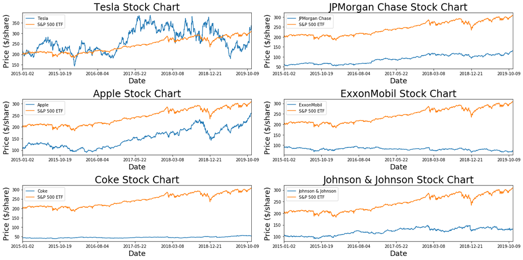

```python
stocks = [TSLA, JPM, AAPL, XOM, KO, JNJ]

s = 1
plt.figure(figsize=(18,9))

for stock in stocks:

    # create a copy of the dataframe, as we will do some manipulations for plotting that we don't want saved
    temp = stock.copy()
    temp.set_index('Date',inplace=True)

    # plot the data
    plt.subplot(3,2,s)
    temp.Close.plot(label = stock.name)
    SPY.Close.plot(label = 'S&P 500 ETF')
    plt.legend(loc = 'best')
    plt.ylabel('Price ($/share)',fontsize=18)
    plt.xlabel('Date',fontsize=18)
    plt.title('{} Stock Chart'.format(stock.name),fontsize=24)
    s+=1

plt.tight_layout()
plt.show()
```

That looks a bit busy; let's try normalizing to the first data point so we can see how each stock has done on a relative basis.

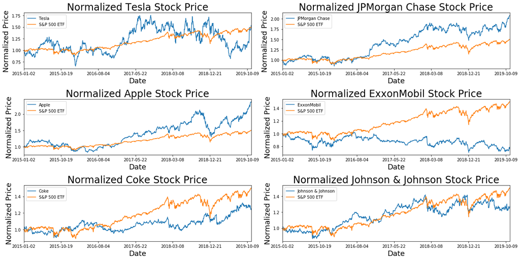

```python
s = 1
plt.figure(figsize=(18,9))

# make new dataframe that's a copy of the S&P Index
SPYtemp = SPY.copy()
SPYtemp.Close = SPYtemp.Close/SPYtemp.Close[0]

for stock in stocks:

    # create a copy of the dataframe, as we will do some manipulations for plotting that we don't want saved
    temp = stock.copy()
    temp.Close = temp.Close/temp.Close[0]
    temp.set_index('Date',inplace=True)

    # plot the data
    plt.subplot(3,2,s)
    temp.Close.plot(label = stock.name)
    SPYtemp.Close.plot(label = 'S&P 500 ETF')
    plt.legend(loc = 'best')
    plt.ylabel('Normalized Price',fontsize=18)
    plt.xlabel('Date',fontsize=18)
    plt.title('Normalized {} Stock Price'.format(stock.name),fontsize=24)
    s+=1

plt.tight_layout()
plt.show()
```

From this plot, we can glean some interesting trends: some stocks have been more volatile than others relative to the index; some have outperformed while others have underperformed; and some appear to have positive correlation (JPM, JNJ, KO, AAPL) while TSLA does not appear to be correlated with the marke tand XOM appears to be negatively correlated. We can test this intution explicitly as well:

```python
for stock in stocks:
    print('{} correlation with the S&P 500 ETF index fund: '.format(stock.name).ljust(63),
          str(np.round(np.corrcoef(stock.Close,SPY.Close)[0,1],2)).rjust(5))
```

```
Tesla correlation with the S&P 500 ETF index fund:               0.53
JPMorgan Chase correlation with the S&P 500 ETF index fund:      0.97
Apple correlation with the S&P 500 ETF index fund:               0.95
ExxonMobil correlation with the S&P 500 ETF index fund:         -0.47
Coke correlation with the S&P 500 ETF index fund:                0.75
Johnson & Johnson correlation with the S&P 500 ETF index fund:   0.85
```

Our intuition appears to hold, though Tesla has stronger correlation than we initially thought. Next we'll look at Tesla specifically and see what the features look like that we engineered in the processing step, above.

```python
df = process(TSLA,SPY)
df.name = TSLA.name
print(df.name)
df.head()
```

```
Tesla
```

|  | Date | Open | High | Low | Close | Adj Close | Volume | SMA_1 | Ret_1 | M_1 | ... | Beta_21 | M_21 | SMA_62 | Ret_62 | Beta_62 | M_62 | Oscillator | Indicator | MACD | Target |
| --- | --- | --- | --- | --- | --- | --- | --- | --- | --- | --- | --- | --- | --- | --- | --- | --- | --- | --- | --- | --- | --- |
| 0 | 2015-01-02 | 222.869995 | 223.250000 | 213.259995 | 219.309998 | 219.309998 | 4764400 | 219.309998 | -0.015973 | -9.220002 | ... | 0.700435 | -0.949997 | 202.246614 | 0.000954 | 0.498438 | -28.309998 | 0.841894 | 0.719706 | 0.000000 | 0 |
| 1 | 2015-01-05 | 214.550003 | 216.500000 | 207.160004 | 210.089996 | 210.089996 | 5368500 | 210.089996 | -0.020788 | -9.220002 | ... | 0.700435 | -0.949997 | 202.246614 | 0.000954 | 0.498438 | -28.309998 | 0.585113 | 0.719706 | -0.206859 | 0 |
| 2 | 2015-01-06 | 210.059998 | 214.199997 | 204.210007 | 211.279999 | 211.279999 | 6261900 | 211.279999 | 0.005808 | 1.190003 | ... | 0.700435 | -0.949997 | 202.246614 | 0.000954 | 0.498438 | -28.309998 | 0.732110 | 0.719706 | -0.226678 | 1 |
| 3 | 2015-01-07 | 213.350006 | 214.779999 | 209.779999 | 210.949997 | 210.949997 | 2968400 | 210.949997 | -0.011249 | -0.330002 | ... | 0.700435 | -0.949997 | 202.246614 | 0.000954 | 0.498438 | -28.309998 | 0.765892 | 0.694372 | -0.242051 | 0 |
| 4 | 2015-01-08 | 212.809998 | 213.800003 | 210.009995 | 210.619995 | 210.619995 | 3442500 | 210.619995 | -0.010291 | -0.330002 | ... | 0.700435 | -0.949997 | 202.246614 | 0.000954 | 0.498438 | -28.309998 | 0.816185 | 0.771396 | -0.258440 | 0 |

5 rows × 26 columns

Let's start by looking at the simple moving averages for the past week, month, and quarter. We'll look at this data from the beginning of 2019. We'll do the same for simple moving return average, rolling beta, and momemtum as well.

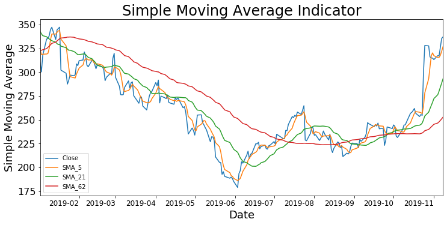

```python
fig, ax = plt.subplots(figsize=(12,6))

df[df['Date'] >= '01-01-2019'].set_index('Date')[['Close','SMA_5','SMA_21','SMA_62']].plot(ax=ax);

titles = 24
axsize = 18

ax.set_title('Simple Moving Average Indicator', fontsize=titles)
ax.set_ylabel('Simple Moving Average',fontsize=axsize)
ax.set_xlabel('Date', fontsize=axsize)
ax.tick_params(axis="x", labelsize=12,rotation=0)
ax.tick_params(axis="y", labelsize=16)
plt.legend();
```

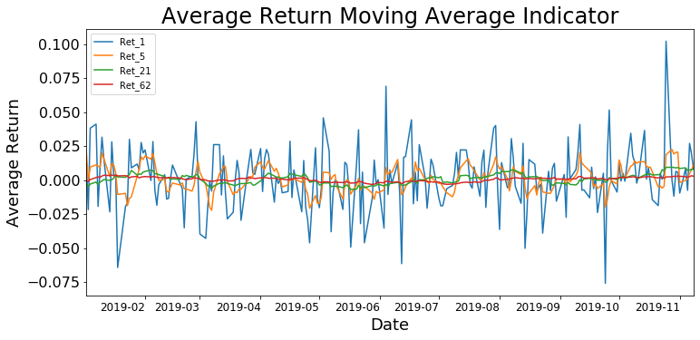

```python
fig, ax = plt.subplots(figsize=(12,6))

df[df['Date'] >= '01-01-2019'].set_index('Date')[['Ret_1','Ret_5','Ret_21','Ret_62']].plot(ax=ax);

ax.set_title('Average Return Moving Average Indicator', fontsize=titles)
ax.set_ylabel('Average Return',fontsize=axsize)
ax.set_xlabel('Date', fontsize=axsize)
ax.tick_params(axis="x", labelsize=12,rotation=0)
ax.tick_params(axis="y", labelsize=16)
plt.legend();
```

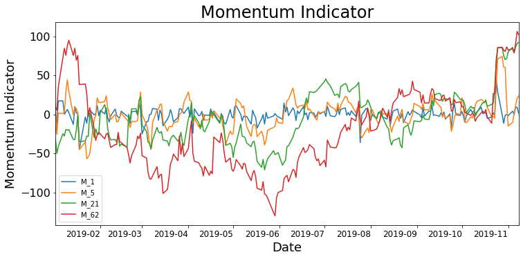

```python
fig, ax = plt.subplots(figsize=(12,6))

df[df['Date'] >= '01-01-2019'].set_index('Date')[['M_1','M_5','M_21','M_62']].plot(ax=ax);

ax.set_title('Momentum Indicator', fontsize=titles)
ax.set_ylabel('Momentum Indicator',fontsize=axsize)
ax.set_xlabel('Date', fontsize=axsize)
ax.tick_params(axis="x", labelsize=12,rotation=0)
ax.tick_params(axis="y", labelsize=16)
plt.legend();
```

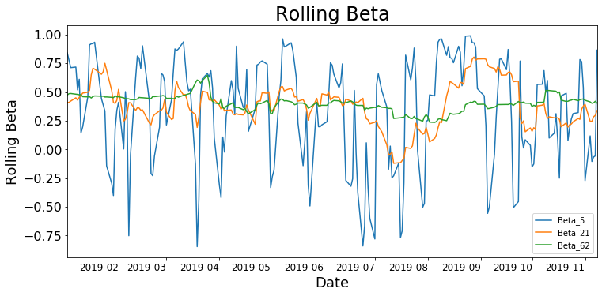

```python
fig, ax = plt.subplots(figsize=(12,6))

df[df['Date'] >= '01-01-2019'].set_index('Date')[['Beta_5','Beta_21','Beta_62']].plot(ax=ax);

ax.set_title('Rolling Beta', fontsize=titles)
ax.set_ylabel('Rolling Beta',fontsize=axsize)
ax.set_xlabel('Date', fontsize=axsize)
ax.tick_params(axis="x", labelsize=12,rotation=0)
ax.tick_params(axis="y", labelsize=16)
plt.legend();
```

## Build some intuition on the above

There's not much to be said about the simple moving average. It merely smooths the volatility in the price of the security and does so in a lagging manner. Some argue that the monthly or quarterly moving average is a more true indicator of the underlying value of a stock and that when a stock price exceeds two standard deviations from this price, it may be a strong buy or sell signal.

The smoothed return data don't tell us much. The number of positive and negative movements for tesla were roughly the same and the stock ended the period around the same price as the beginning of the period, so we would expect that the longer the perioed used in the average, the smoother and closer to zero, which is what we observe.

Momentum is the empirically observed tendency for rising asset prices to rise further, and falling prices to keep falling. For instance, it was shown that stocks with strong past performance continue to outperform stocks with poor past performance in the next period. Momentum can be caluated for an arbitrary period. From our analysis, we can see that the longer the period used to calculate this indicator, the more variability is shown in the data. It is interesting to note that for the 1 quarter momentum period, once the stock momentum started to change direction, it tended to continue until eventually reversing (*i.e.*, the volatility was further spread out than for the shorter momentum periods). This aspect could be interesting to explore as a potential signal for a trading strategy as well as for predicting future binary changes (*i.e.*, rise or fall) in stock prices, which we'll look at below.

We'll first test the machine learning algorithm with all factors, below; then we'll remove some of the factors that at first glance appear to be largely noise (*e.g.*, the shorter rolling beta periods) to see whether this improves our predictive capabilities.

Before that, though, let's look at the final few indicators: the oscillator indicators and MACD.

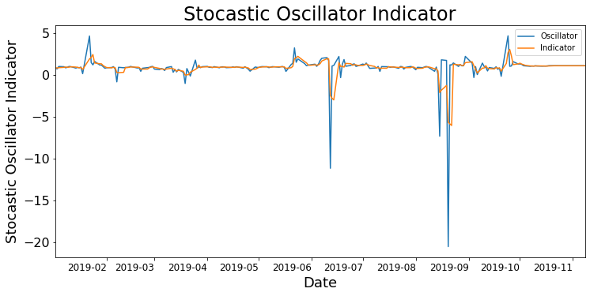

```python
fig, ax = plt.subplots(figsize=(12,6))

df[df['Date'] >= '01-01-2019'].set_index('Date')[['Oscillator','Indicator']].plot(ax=ax);

ax.set_title('Stocastic Oscillator Indicator', fontsize=titles)
ax.set_ylabel('Stocastic Oscillator Indicator',fontsize=axsize)
ax.set_xlabel('Date', fontsize=axsize)
ax.tick_params(axis="x", labelsize=12,rotation=0)
ax.tick_params(axis="y", labelsize=16)
plt.legend();
```

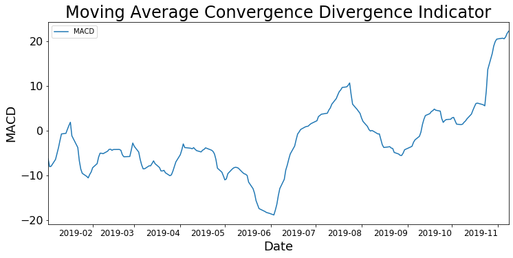

```python
fig, ax = plt.subplots(figsize=(12,6))

df[df['Date'] >= '01-01-2019'].set_index('Date')['MACD'].plot(ax=ax);

ax.set_title('Moving Average Convergence Divergence Indicator', fontsize=titles)
ax.set_ylabel('MACD',fontsize=axsize)
ax.set_xlabel('Date', fontsize=axsize)
ax.tick_params(axis="x", labelsize=12,rotation=0)
ax.tick_params(axis="y", labelsize=16)
plt.legend();
```

Finally, the MACD is designed to reveal changes in the strength, direction, momentum, and duration of a trend in a stock's price. It is primarily used as a tool to guide trading strategies, but we'll see how useful it is in predicting price movements.

### Machine Learning Model

Next, let's run the machine learning model. We'll use a random forest classifier with a grid search over a few key hyperparameters (the number of estimators, minimum samples per split, and minimum samples per leaf); we'll also look at how good of a job we can do predicting price movements further out into the future—between one day and one month ahead.

Before we dig in, an aside on how we'll be doing the cross-validation. It's not appropriate to do random train-test splits or conventional k-fold cross-validation on time series data, as doing so leaks data from the future into the model (*i.e.*, these approaches future-bias the model). It also doesn't make sense to use some amount of historical data to predict a subset of more recent data in a single shot, as that introduces recency bias. Time series split is an alternative approach. This method entails dividing the training set into two folds at each iteration, ensuring that the validation set is always ahead of the training split. The following block of code illustrates this appraoch with the Tesla data.

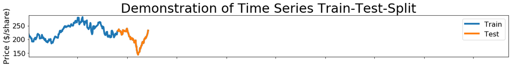

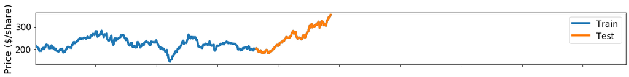

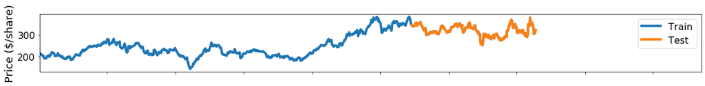

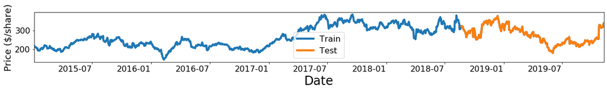

```python
splits = 4

for split in range(1,splits+1):
    lim  = int(split/splits*len(df))
    idx  = int(0.75*lim)


    train = df.iloc[:lim][['Date','Close']]
    train.rename(columns = {'Close':'Train'},inplace=True)

    test  = df.iloc[idx:lim,:][['Date','Close']]
    test.rename(columns = {'Close':'Test'},inplace=True)

    data = train.merge(test,left_on='Date',right_on='Date',how='outer')

    ax = data.plot(x='Date',y=['Train','Test'],figsize=(20,2),linewidth=4)
    ax.set_xlim([735600,737371])
    ax.legend(fontsize=16)
    ax.set_ylabel('Price ($/share)',fontsize=18)

    for tick in ax.yaxis.get_major_ticks():
        tick.label.set_fontsize(16)

    if split == 1:
        ax.set_title('Demonstration of Time Series Train-Test-Split',fontsize=30)

    if split != splits:
        ax.set_xticklabels([])
        ax.set_xlabel('')

    if split == splits:
        ax.tick_params(axis="x", labelsize=16,rotation=0)
        ax.set_xlabel('Date',fontsize=24)
```

```python
periods = 22

results = pd.DataFrame(columns=['Company','Period','Accuracy','Random Chance','min_samples_leaf', 'min_samples_split', 'n_estimators'])


for p in range(1,periods):
    start = time.time()

    for stock in stocks:
        df = process(stock,SPY)
        X, Y = get_features(df,p)

        model = RandomForestClassifier(random_state=5)

        param_search = {'n_estimators': [25,100,250],
                        'min_samples_split': [2, 10, 20],
                        'min_samples_leaf': [2, 10, 20]}

        tscv = TimeSeriesSplit(n_splits=5)
        gsearch = GridSearchCV(estimator = model,
                               cv = tscv,
                               param_grid = param_search)

        gsearch.fit(X,Y.values.ravel())

        best = gsearch.best_score_* 100.0
        leaf = gsearch.best_params_['min_samples_leaf']
        samp = gsearch.best_params_['min_samples_split']
        ests = gsearch.best_params_['n_estimators']

        results.loc[len(results)] = [stock.name, p, best, Y.mean()[0]*100, leaf, samp, ests]

    print('Period {} run time: '.format(str(p)).ljust(20),'{}s'.format(round(time.time()-start,1)))
```

```
Period 1 run time:   125.4s
Period 2 run time:   121.0s
Period 3 run time:   154.7s
Period 4 run time:   124.7s
Period 5 run time:   132.2s
Period 6 run time:   125.4s
Period 7 run time:   121.5s
Period 8 run time:   120.9s
Period 9 run time:   121.7s
Period 10 run time:  126.0s
Period 11 run time:  130.8s
Period 12 run time:  126.0s
Period 13 run time:  126.4s
Period 14 run time:  126.9s
Period 15 run time:  127.5s
Period 16 run time:  126.3s
Period 17 run time:  121.2s
Period 18 run time:  122.1s
Period 19 run time:  125.6s
Period 20 run time:  122.1s
Period 21 run time:  125.0s
```

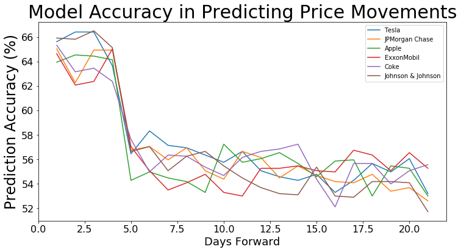

```python
fig, ax = plt.subplots(figsize=(12,6))

for stock in stocks:
    ax.plot(np.linspace(1,21,21),results[results['Company'] == stock.name]['Accuracy'],label=stock.name);

ax.set_title('Model Accuracy in Predicting Price Movements', fontsize=30)
ax.set_ylabel('Prediction Accuracy (%)',fontsize=24)
ax.set_xlabel('Days Forward', fontsize=axsize)
ax.tick_params(axis="x", labelsize=16,rotation=0)
ax.tick_params(axis="y", labelsize=16)
plt.legend();
```

```python
results[results['Period'] == 1][['Company','Accuracy','Random Chance']]
```

|  | Company | Accuracy | Random Chance |
| --- | --- | --- | --- |
| 0 | Tesla | 65.615764 | 50.367948 |
| 1 | JPMorgan Chase | 65.024631 | 52.739166 |
| 2 | Apple | 63.940887 | 52.657400 |
| 3 | ExxonMobil | 64.630542 | 48.405560 |
| 4 | Coke | 65.320197 | 51.512674 |
| 5 | Johnson & Johnson | 65.911330 | 51.267375 |

### Review results

As noted above, there are some indicators that appear little more than noise. In the following, we'll select a curated list, guided by intuition more than anything, to see if we can improve upon these results (an alternative approach would be to build the model by systemating adding or removing factors to guague the predictive capabilities of each factor and select the set that does best). Here, we'll try an intuitive approach, using the following indicators:

- All simple moving averages
- Quarterly rolling average for momentum, beta, and returns
- 3-day average stochastic oscillator indicator
- MACD

```python
periods = 22

results2 = pd.DataFrame(columns=['Company','Period','Accuracy','Random Chance','min_samples_leaf', 'min_samples_split', 'n_estimators'])


for p in range(1,periods):
    start = time.time()

    for stock in stocks:
        df = process(stock,SPY)
        X, Y = get_features(df,p)

        drop_cols = ['Ret_1','Ret_5','Ret_21','M_1','M_5','M_21','Beta_5','Beta_21','Oscillator']
        X.drop(drop_cols,axis=1,inplace=True)

        model = RandomForestClassifier(random_state=5)

        param_search = {'n_estimators': [25,100,250],
                        'min_samples_split': [2, 10, 20],
                        'min_samples_leaf': [2, 10, 20]}

        tscv = TimeSeriesSplit(n_splits=5)
        gsearch = GridSearchCV(estimator = model,
                               cv = tscv,
                               param_grid = param_search)

        gsearch.fit(X,Y.values.ravel())

        best = gsearch.best_score_*100.0
        leaf = gsearch.best_params_['min_samples_leaf']
        samp = gsearch.best_params_['min_samples_split']
        ests = gsearch.best_params_['n_estimators']

        results2.loc[len(results2)] = [stock.name, p, best, Y.mean()[0]*100, leaf, samp, ests]

    print('Period {} run time: '.format(str(p)).ljust(20),'{}s'.format(round(time.time()-start,1)))
```

```
Period 1 run time:   105.3s
Period 2 run time:   103.1s
Period 3 run time:   112.3s
Period 4 run time:   104.8s
Period 5 run time:   106.0s
Period 6 run time:   106.1s
Period 7 run time:   107.3s
Period 8 run time:   106.9s
Period 9 run time:   106.7s
Period 10 run time:  106.4s
Period 11 run time:  107.7s
Period 12 run time:  106.5s
Period 13 run time:  105.7s
Period 14 run time:  105.7s
Period 15 run time:  113.7s
Period 16 run time:  112.8s
Period 17 run time:  109.1s
Period 18 run time:  105.2s
Period 19 run time:  106.5s
Period 20 run time:  105.3s
Period 21 run time:  105.4s
```

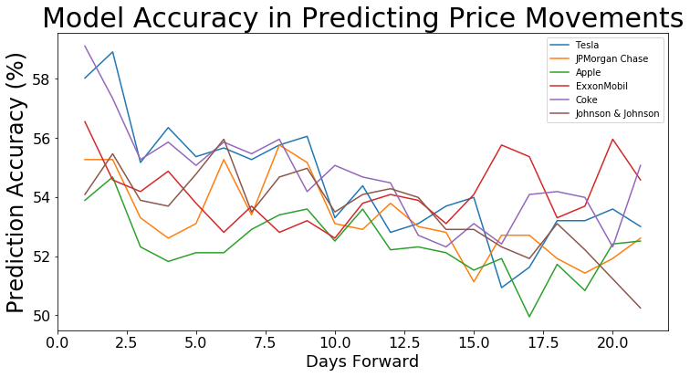

```python
fig, ax = plt.subplots(figsize=(12,6))

for stock in stocks:
    ax.plot(np.linspace(1,21,21),results2[results2['Company'] == stock.name]['Accuracy'],label=stock.name);

ax.set_title('Model Accuracy in Predicting Price Movements', fontsize=30)
ax.set_ylabel('Prediction Accuracy (%)',fontsize=24)
ax.set_xlabel('Days Forward', fontsize=axsize)
ax.tick_params(axis="x", labelsize=16,rotation=0)
ax.tick_params(axis="y", labelsize=16)
plt.legend();
```

It looks like our intuition wasn't too helpful in improving accuracy—the second version of the model lost ground in accuracy, especially for the first few prediction intervals, but also for the longer term.

### Concluding thoughts

The market generally trends up, so the further out you look, the more likely it is that the market will go up based on the underlying trend (*i.e.*, we invest because we expect the market to go up, and becuase we expect the market to go up, we invest, driving the cycle). Given this fact, it is a little surprising that the accuracy goes down in this model; that is, the model is not designed to capture this effect. More careful consideration of how the indicators are used to predict (*i.e.*, we didn't actually use the underlying stock price itself as a feature, which may help in teasing out this trend). Nevertheless, our model does a beter job than random guessing— it's better than employing a strategy that always guesses increase, for example, but it doesn't necessarily guide an investment strategy. That's a topic for another day!